# Gendered Differences of Stress During the 2008 Economic Recession

Cassie Yu

Yoonseo Bae

Angelina Chen

2025-04-30

# Introduction

The 2008 economic recession precipitated unprecedented financial instability, disrupting gendered labor dynamics and exacerbating stress disparities. This study examines how economic stress—defined as acute financial uncertainty and employment precarity—manifested differentially by gender during this period, with a focus on mediating factors such as employment sector, caregiving responsibilities, and societal expectations. While chronic stress literature broadly links stress to neurobiological and cardiovascular outcomes (McEwen et al., 2017; Esch et al., 2002), this analysis narrows its scope to the intersection of financial stress and gender, a critical gap given that men experienced disproportionate job losses in male-dominated industries (e.g., 72% of construction/manufacturing layoffs; Starr, 2014), while married women’s employment rose 5.2% as they assumed breadwinning roles (BLS, 2008).

Gendered stress disparities are well-documented: women exhibit higher rates of stress-precipitated depression (Kuehner, 2017), whereas men are more vulnerable to stress-related substance use disorders (Boughner & Frewen, 2016). However, prior studies neglect how systemic economic shocks amplify these disparities, relying on clinician-reported data (Heretick, 2013) or limited mental health indicators (Dagher et al., 2015). This study addresses these limitations by analyzing direct self-reports from the Stress in America survey (APA, 2008), which captures granular data on stress sources, coping mechanisms, and health outcomes stratified by gender.

We chose the Stress in America dataset (2007-2009) because it offers a timely, nationally representative snapshot of psychological and physiological responses to financial stress during a major economic crisis. Unlike clinical datasets, it reflects self-reported perceptions of stress, allowing us to analyze not just mental health symptoms, but also coping styles, physical health complaints, and gendered responsibilities (e.g., caregiving and employment). This comprehensive, multidimensional structure enables us to make a more holistic exploration of how gender shapes the experience of economic stress and its downstream consequences.

**Research Question:** How did stress experiences and coping mechanisms differ by gender during the 2008 economic crisis, and how were these differences linked to psychological and physical health outcomes?

# Ethical Consideration

When working with survey data that captures sensitive personal information—such as stress levels, coping mechanisms, employment status, and health outcomes—it is crucial to handle the data ethically to protect respondents’ privacy and dignity. In the context of the APA’s “Stress in America” survey dataset, several specific considerations are particularly important.

First, although the dataset has been anonymized, variables such as employment status combined with detailed stress indicators could risk re-identification when filtered into smaller subgroups. Therefore, we are careful to report only aggregated results without singling out small or potentially identifiable groups.

Second, the data reflects individuals’ experiences during a period of economic hardship (2007–2009), when financial stress and mental health issues were especially heightened. Recognizing the vulnerability of the respondents, we approach the analysis with sensitivity, avoiding framing that could blame individuals for their stress responses or imply personal failure.

Third, issues of sampling bias must be acknowledged. Because participation in online surveys may be influenced by internet access, willingness to disclose sensitive information, there may be underrepresented in the data. We keep these limitations in mind when interpreting and generalizing our results.

Finally, beyond technical confidentiality, ethical analysis also involves critical reflection on the societal implications of our findings. When discussing gendered stress differences, for example, we aim not to reinforce stereotypes but to highlight systemic factors that might explain disparities.

```r
data <- read.delim(file = "./data/37288-0003-Data.tsv", sep = '\t', header = TRUE)
```

# Data Cleaning

Before analysis, we need to clean and prepare the data to ensure that our results are meaningful and reliable. Given the breadth of the survey, which includes numerous variables on stressors, symptoms, and coping strategies,about 4050 attributes, we narrowed our focus to variables most relevant to our research goals: stress levels, coping mechanisms, employment status, and gender.

Focusing on these variables allows us to address key research questions about how economic stressors during the 2008 crisis affected people differently across demographic lines.By reducing the dataset to a manageable and targeted subset, we can conduct a more focused and interpretable analysis.

The variables used in our analysis are:

- **DMAGE**: Age of the respondent.
- **Q268R1**: Gender identity (**Male**).
- **Q268R2**: Gender identity (**Female**).
- **Q268R3**: Gender identity (**Transgender**).
- **Q268R4**: Gender identity (**Other**).
- **Q268R5**: Gender identity (**Non-binary/Genderqueer/Gender Fluid**).
- **Q1406**: Metropolitan Statistical Area (**MSA**) code.
- **Q605**: Stress level in the past month (**Scale: 1-10**).
- **DMMARSTAT**: Marital status.

We decided to use these variables because we were interested in how stress affected different genders.

```r
# Selecting only the relevant variables to our analysis
cleaned_data <- data %>%
  select(UNIQUE, DMAGE, Q268R1, Q268R2, Q268R3, Q268R4, Q268R5, Q1406, Q605, Q635, Q1720, DMMARSTAT, Q610, Q1500)
```

```r
# Renaming variables for clarity
cleaned_data <- cleaned_data %>%
  rename(
    Age = DMAGE,
    Male = Q268R1,
    Female = Q268R2,
    Transgender = Q268R3,
    Other_Gender = Q268R4,
    Non_Binary = Q268R5,
    MSA_Code = Q1406,
    Stress_Level = Q605,
    Stress_Before_Mental_Health = Q1720,
    Marital_Status = DMMARSTAT
  )
```

In multiple columns, ‘NA’ is the most common row value. This is likely due to the nature of the survey, which allows participants to answer only the questions they want to answer. To ensure our analysis is not biased we removed rows with missing values. We also did some cautionary cleaning so that values such as “age” and “stress levels” did not contain invalid responses such as negative numbers.

```r
# Remove rows with missing or invalid values for key variables
cleaned_data <- cleaned_data %>%
  filter(!is.na(Age), !is.na(Stress_Level), Age > 0, Stress_Level > 0)
```

# Analysis of Distribution of Individual Variables

## Exploratory Analysis of Age

To get a better sense of who the survey’s participants are, we decided to take a look at their ages. This was the response to the question on the survey: “What is your age?”

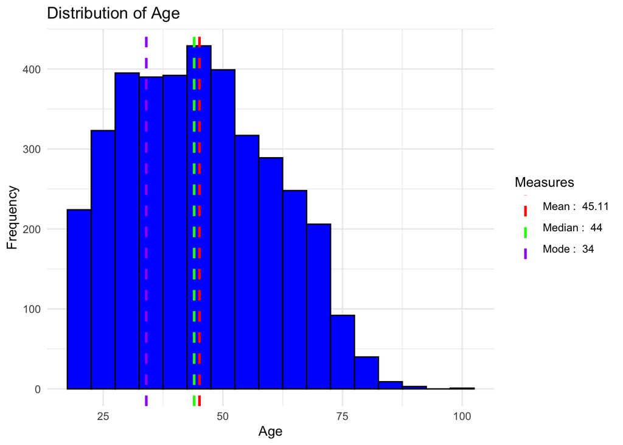

From this information, we can infer that most people who participate in this study are around 45. There are more younger individuals around 34, but the presence of older individuals increases the mean. Thus the target age range for this study is people in their 30s and 40s, with older individuals as the tail of the distribution.

## Distribution of Stress Levels

The question on survey talking about stress levels is: On a scale of 1 to 10, where 1 means you have “little or no stress” and 10 means you have “a great deal of stress,” how would you rate your average level of stress during the past month?

To analyze participants basic understanding of their stress levels, we used ggplot again to create a histogram.

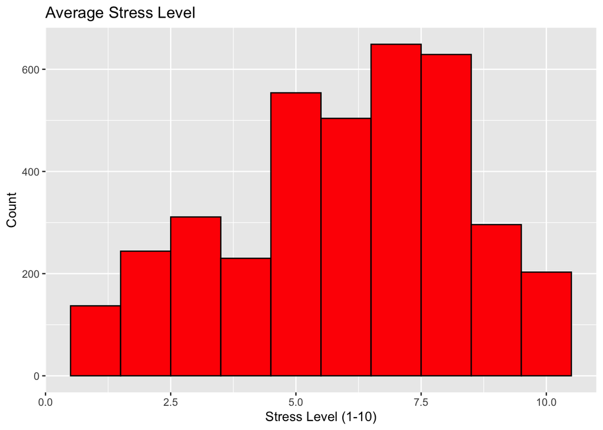

Based on the fact that the 30s and 40s represent the average age range in the dataset, the red histogram shows that individuals in this age group typically experience a stress level of around 7.5, with a skew toward higher stress ratings.

## Exploratory Analysis of Gender

We investigate how stress experiences varied by gender. Prior research suggests that stress exposure and coping mechanisms can differ significantly between men and women, especially during economic downturns. We aim to explore whether such patterns emerge in this dataset as well.

This was the response to the survey question: “How do you describe yourself?”

```
## Number of '1' responses for Male: 1553
##  Number of '1' responses for Female: 2204
##  Sum of Male and Female responses: 3757
##  Sample size: 3757
##  Does the sum of Male and Female equal the sample size? TRUE
```

To make it easier to see who in the dataset was female and who was male, we created a new column called “Gender_Identity.” Previously ‘Male’ and ‘Female’ were in seperate columns, now we have unified them into one column for easier viewing.

```r
# We used the function mutate() to modify the column 'Gender_Identity' using a conditional clause.

cleaned_data <- cleaned_data %>%
  mutate(
    Gender_Identity = case_when(
      Male == 1 ~ "Male",
      Female == 1 ~ "Female"
    )
  )
```

Respondents who selected 1 for ‘Male’ or ‘Female’ are now categorized accordingly. The other three response categories (Transgender, Other_Gender, Non_Binary) can be disregarded as we have confirmed above that all respondents answered the ““How do you describe yourself?” question as either Male or Female.

To help visualize the number of males and females in our data, we created a bar graph similar to the one for “age.” It is color coded pink (for ‘female’) and blue (for ‘male’).

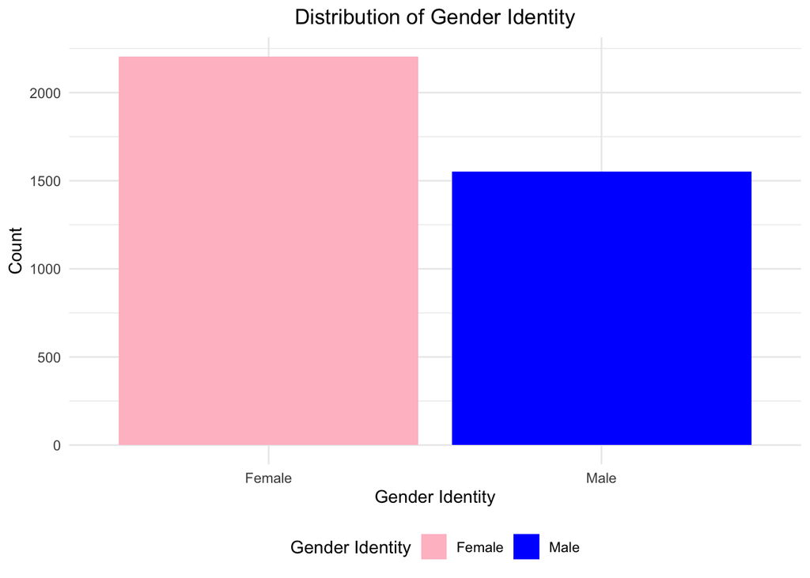

Looking at this bar graph, the fact that more females responded to the survey could mean that women in their 30s and 40s are more willing to discuss how they feel and therefore, may be more likely to seek help about their stress levels. It could also mean that women feel more stress, which is why they feel more compelled to complete this survey.

To further investigate potential drivers behind this disparity, we next examine whether geographic context (captured by Metropolitan Statistical Area, or MSA) may contribute to variations in stress. Prior studies have shown that urban environments and regional economic conditions can influence stress levels (BLS, 2008).

## Distribution of Respondents by Metropolitan Statistical Area (MSA)

To understand where in the US the survey’s participants are from, we performed exploratory analysis of respondents metropolitan origin. This helps provide context for interpreting stress patterns across different urban regions in the United States.

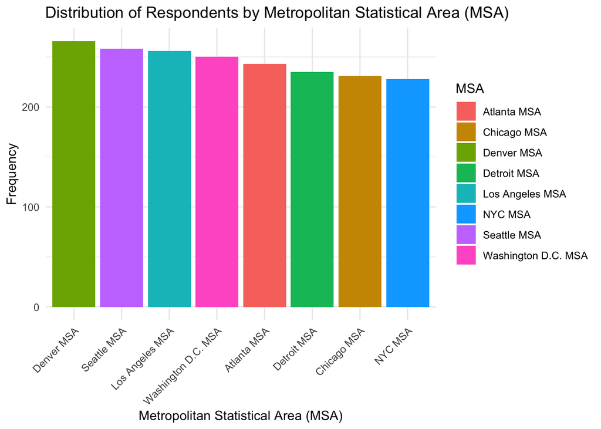

```r
mode_msa <- msa_freq %>%
  arrange(desc(Frequency)) %>%
  slice(1) %>%
  pull(MSA)
total_valid <- sum(msa_freq$Frequency)
total_missing <- nrow(cleaned_data) - total_valid
cat("Most Frequent MSA (Mode):", mode_msa, "\n")
```

```
## Most Frequent MSA (Mode): Denver MSA
```

```r
cat("Total Valid Responses:", total_valid, "\n")
```

```
## Total Valid Responses: 1967
```

```r
cat("Total Missing Responses:", total_missing, "\n")
```

```
## Total Missing Responses: 1790
```

We used code to determine the most frequent MSA, which is Denver. Then we wanted to see how many missing values there were for this attribute. Since there are almost as many missing values as valid values, we can infer that participants did not want to share where they were located. This may be due to confidentiality reasons.

# Analysis of Correlation Between Variables

After examining individual distributions of stress and demographic variables, we next analyze correlations to understand how these factors relate to one another. We begin with the relationship between age and stress to assess whether the target age range of survey respondents, primarily adults in their 30s to 40s, is associated with higher reported stress levels. This helps verify whether stress is concentrated in particular life stages, as suggested by prior research on work-life balance and financial strain in mid-adulthood.

First we analyzed the correlation between age and stress to see if the target age range for this survey actually had higher stress levels.

## Correlation Between Age and Stress Levels

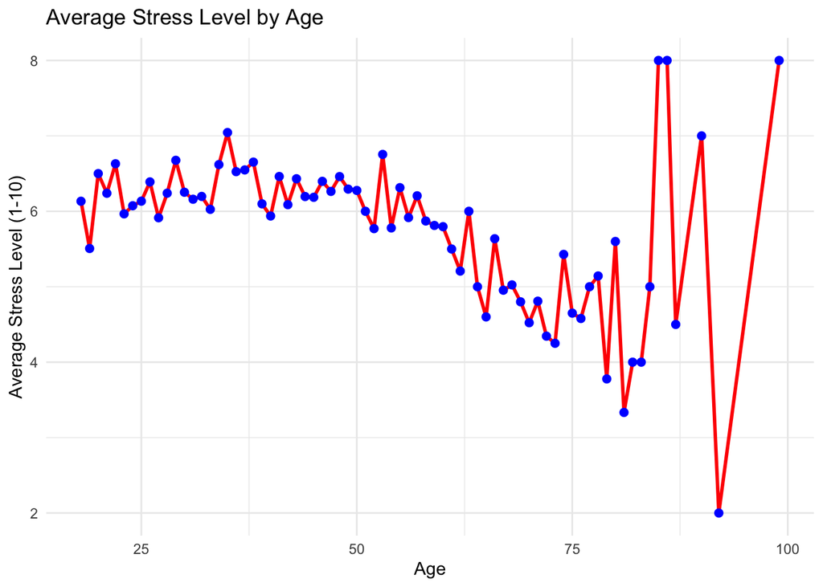

```r
# Here we compute average stress level per age using group_by() to group by age and then calculating the mean stress level for each age.

age_stress_trend <- cleaned_data %>%
  group_by(Age) %>%
  summarize(Average_Stress = mean(Stress_Level, na.rm = TRUE))

# Again we use ggplot to create the line plot. The red line is for trend. The points are blue for each age.
ggplot(age_stress_trend, aes(x = Age, y = Average_Stress)) +
  geom_line(color = "red", size = 1) +
  geom_point(color = "blue", size = 2) +
  labs(
    title = "Average Stress Level by Age",
    x = "Age",
    y = "Average Stress Level (1-10)"
  ) +
  theme_minimal()
```

Here we see that our previous assumption is not necessarily true. Younger individuals (ages 20-40) generally report higher stress levels, fluctuating around 6-7. As age increases, stress levels gradually decline, reaching their lowest around age 70. However, for individuals over 75, stress levels become more erratic, likely due to fewer data points or variability in responses. The overall trend suggests that stress decreases with age, but variability increases in older populations.

While our earlier visualizations suggested that stress tends to decrease with age, particularly after age 40, we wanted to formally test the strength and direction of this relationship. Therefore, we performed a linear regression analysis to quantify the correlation between age and stress levels and determine whether the observed downward trend is statistically significant. This allows us to move from visual intuition to a more rigorous, model-based understanding of how age predicts perceived stress.

```r
# Performing the linear regression using the function lm()
lm_model <- lm(Stress_Level ~ Age, data = cleaned_data)

# Summarizing the regression results
summary(lm_model)
```

```
##
## Call:
## lm(formula = Stress_Level ~ Age, data = cleaned_data)
##
## Residuals:
##     Min      1Q  Median      3Q     Max
## -5.6508 -1.5262  0.2968  1.7482  4.8704
##
## Coefficients:
##              Estimate Std. Error t value Pr(>|t|)
## (Intercept)  7.124676   0.116303   61.26   <2e-16 ***
## Age         -0.024938   0.002439  -10.23   <2e-16 ***
## ---
## Signif. codes:  0 '***' 0.001 '**' 0.01 '*' 0.05 '.' 0.1 ' ' 1
##
## Residual standard error: 2.315 on 3755 degrees of freedom
## Multiple R-squared:  0.0271, Adjusted R-squared:  0.02684
## F-statistic: 104.6 on 1 and 3755 DF,  p-value: < 2.2e-16
```

From the linear regression, we can see that the relationship between age and stress is statistically significant, as the p-value is (<2e-16).

Looking at the information above, we can decifer that:

- For each additional year of age, stress levels is seen to decrease by approximately -0.024938 points on average.
- About 2.71% of the variance in stress levels is explained by age.

## Stress Level before Consideration of Seeking Mental Health Support by Gender Identity

Next we analyzed the relationship between gender and stress level before seeking mental health support. Because there are more women in the study, we wanted to see if this was because they had higher stress levels, and thus, were seeking mental health support. This could also be a reason as to why they felt more compelled to complete this survey about stress.

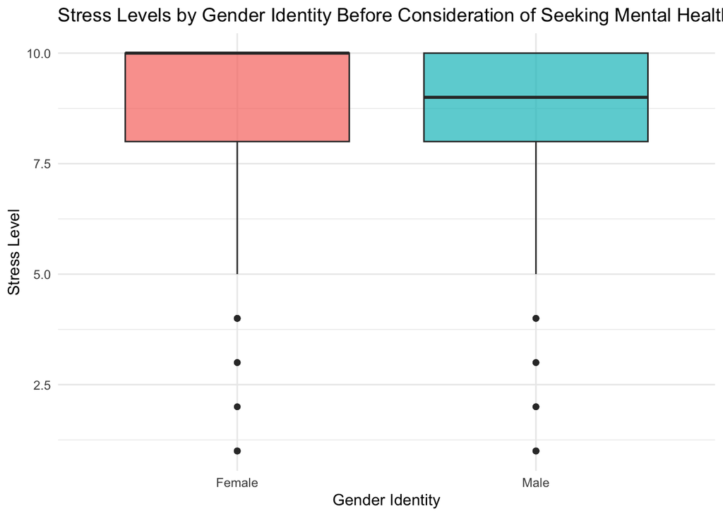

We created boxplots to visually compare the distribution of stress levels between men and women. We have “Female” or “Male” on the x-axis as the two labels, and the stress levels on the y-axis as indications of perceived stress levels: 1 being very little stress and 10 being very large amounts of stress.

However the overall interquartile range is surprisingly similar between the two categories, meaning both men and women were willing to undergo high levels of stress before reaching out to seek support. This could be due to the stigma around mental health support in the early 2000s.

## Stress Levels by Marital Status

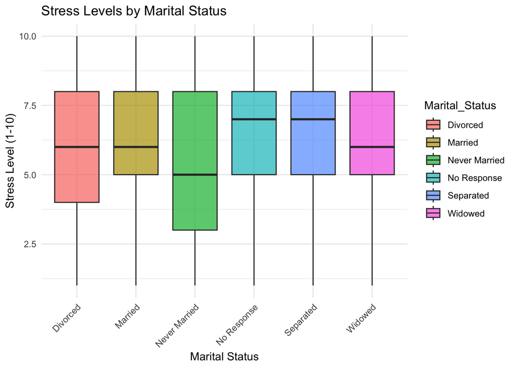

```r
# We first cleaned the "Marital_Status" variable by renaming the numerical response to a string format so it is easier to understand.
cleaned_data <- cleaned_data %>%
  mutate(Marital_Status = case_when(
    Marital_Status == 1 ~ "Married",
    Marital_Status == 2 ~ "Widowed",
    Marital_Status == 3 ~ "Divorced",
    Marital_Status == 4 ~ "Separated",
    Marital_Status == 5 ~ "Never Married",
    TRUE ~ "No Response"
  ))
# Then we used ggplot to create a box plot for each category of marital status.
ggplot(cleaned_data, aes(x = Marital_Status, y = Stress_Level, fill = Marital_Status)) +
  geom_boxplot(alpha = 0.7) +
  labs(title = "Stress Levels by Marital Status",
       x = "Marital Status",
       y = "Stress Level (1-10)") +
  theme_minimal() +
  theme(axis.text.x = element_text(angle = 45, hjust = 1))
```

# Summary of Analysis

Our analysis of the Stress in America dataset shows that stress levels were high across all groups, which makes sense given that this survey was conducted in 2008, right in the middle of the financial crisis. The economy was crashing, unemployment was rising, and many people were losing their homes. Younger adults (20-40) may have been hit the hardest, facing job losses and financial instability just as they were trying to build their futures. This could explain why they reported higher stress levels. The histogram of stress levels showed a strong shift toward higher ratings, suggesting that stress was a widespread problem during this time. Older adults, on the other hand, reported lower stress on average, possibly because they had more financial security or had already lived through other economic downturns and felt more prepared to handle the situation.

Mental health stigma in 2008 was also likely a big factor in the survey results. At the time, people weren’t as open about discussing stress or seeking help as they are today. This could explain why so many responses had missing values (NA) in questions about stress and mental health support. Some participants may have skipped these questions because they weren’t comfortable talking about their struggles. The high number of missing values in the location (MSA) data could also mean that people didn’t want to share personal details, especially in a survey discussing mental health.

Dataset used: American Psychological Association. (2025). Stress in America, United States, 2007–2018 (ICPSR 37288-v2). Inter-university Consortium for Political and Social Research [distributor]. https://doi.org/10.3886/ICPSR37288.v2

Works Cited: Boughner, E., & Frewen, P. (2016). Gender differences in perceived causal relations between trauma-related symptoms and substance use disorders in online and outpatient samples. Traumatology, 22(4), 288–298. https://doi.org/10.1037/trm0000100

Bureau of Labor Statistics (BLS). (2009). The employment situation: December 2008. https://www.bls.gov/news.release/archives/empsit_01092009.pdf

Dagher RK, Chen J, Thomas SB (2015) Gender Differences in Mental Health Outcomes before, during, and after the Great Recession. PLoS ONE 10(5): e0124103. https://doi.org/10.1371/journal.pone.0124103

Esch, T., Stefano, G. B., Fricchione, G. L., & Benson, H. (2002, May 15). (PDF) stress in cardiovascular disease. Medical Science Monitor. https://www.researchgate.net/publication/11359375_Stress_in_cardiovascular_disease

Heretick, D. M. L. (2013). Clinicians’ reports of the impact of the 2008 financial crisis on mental health clients. Journal of Social, Behavioral, and Health Sciences, 7(1), 1–22. https://doi.org/10.5590/JSBHS.2013.07.1.01

Kuehner C. (2017). Why is depression more common among women than among men?. The lancet. Psychiatry, 4(2), 146–158. https://doi.org/10.1016/S2215-0366(16)30263-2

McEwen, B. S. (2017). Neurobiological and systemic effects of chronic stress. Chronic Stress, 1(1), 247054701769232. https://doi.org/10.1177/2470547017692328